# Texan Data

Andy Berrios

2022-04-26

# Where is your future? Where will your next opportunity begin?

# Wether for future investments or a change in scenery let’s take a closer look at Houston, Dallas, and San Antonio!

According to Moving.com, there are three major components to look out for when planning a move or purchase: **Potential Job Perspectives, Cost of Living, and Demographics**.

# First, let’s consider what you need to survive in America: Money!

Each city will have different industries that thrive between it’s borders. Lets compare the different size and growth of all industries as a whole within their respective city!

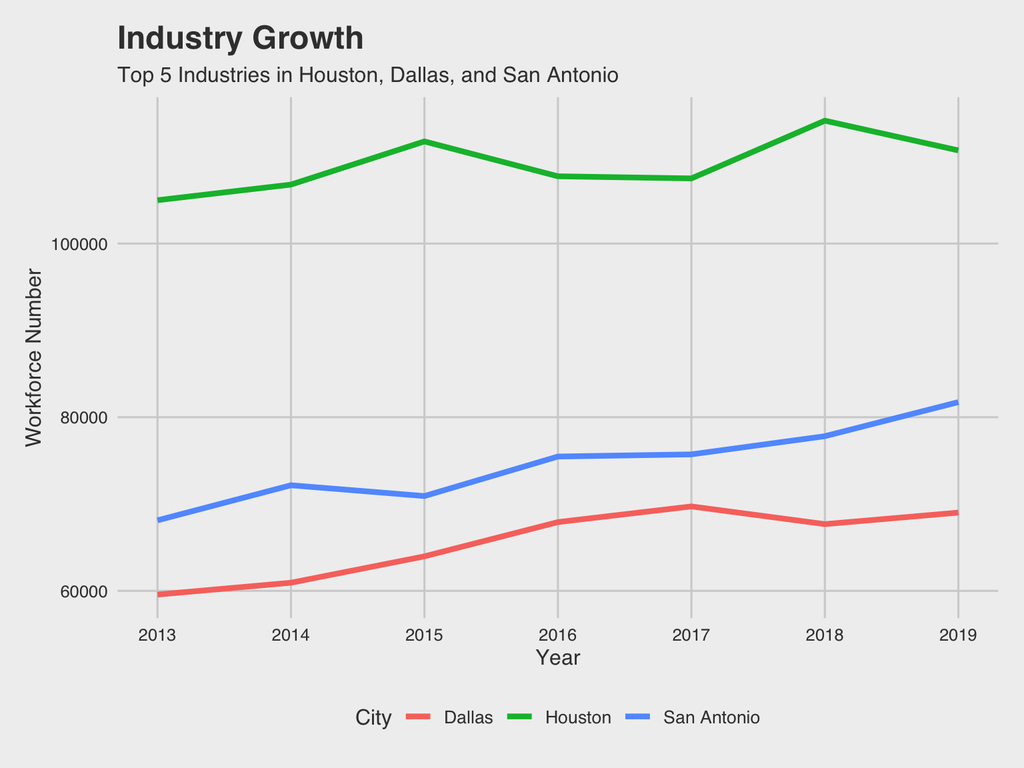

At first glance one would say Houston is the go to place for job potential. However, looks can be deceiving, so lets take a closer look at the industries within each city!

# Houston

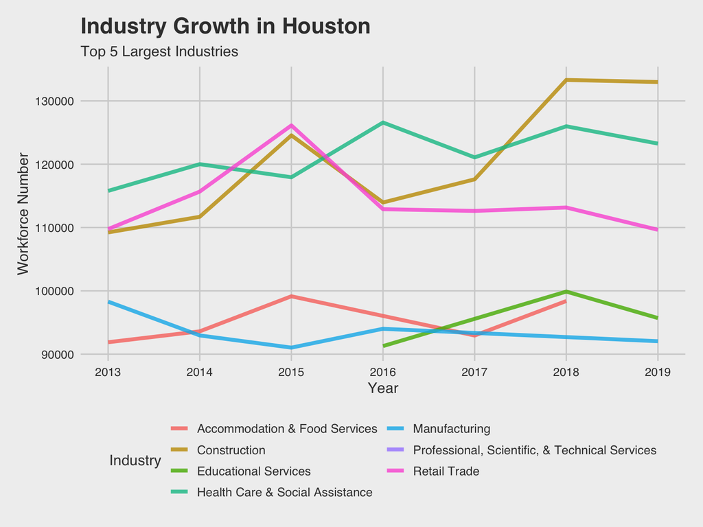

# Dallas

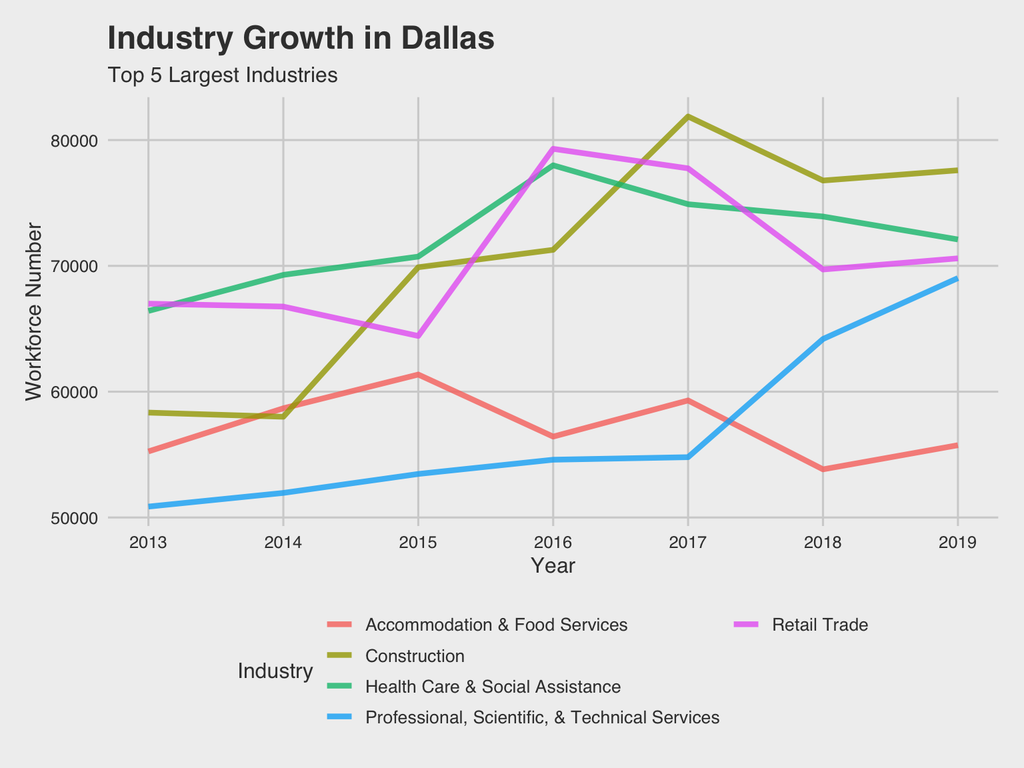

# San Antonio

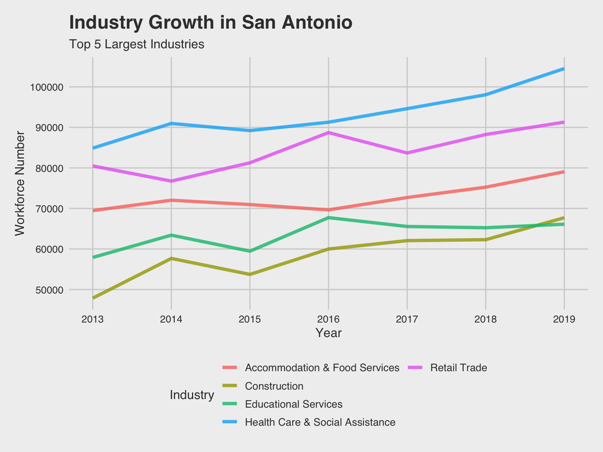

San Antonio comes in with a strong and stable economy with industry growth coming in at 4.10 %!

# Saleries

Now, let’s see how much you could potentially be making in each city!

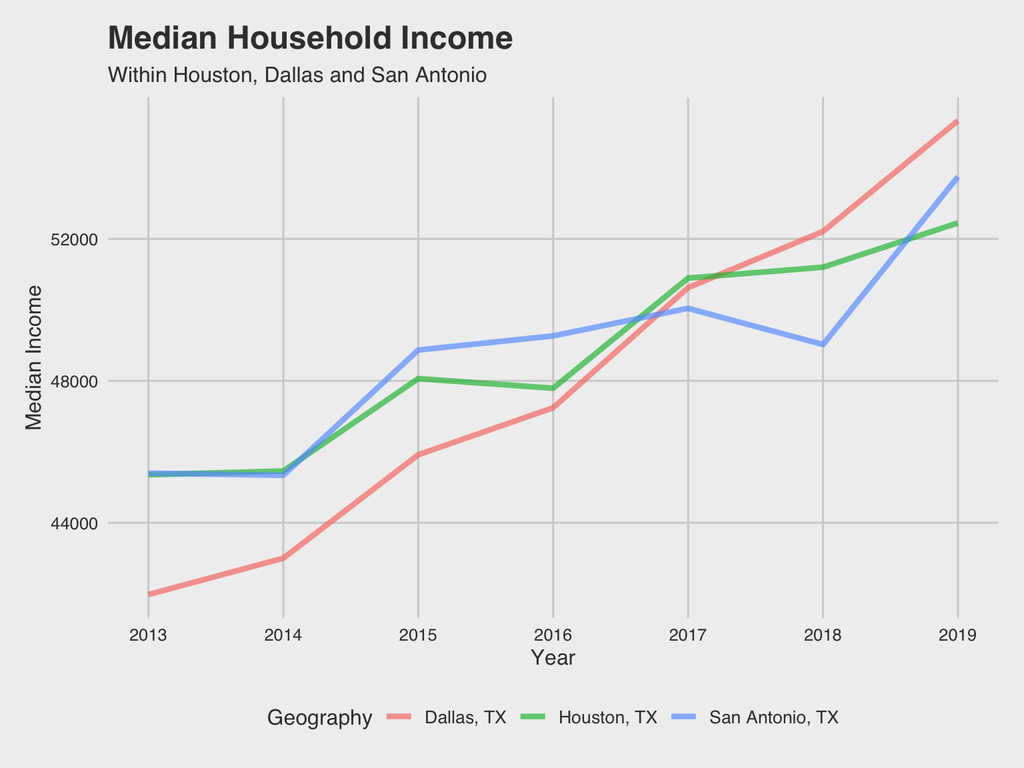

Although all Incomes within their respective city are almost equivalent to each other, Dallas incomes are growing a faster rate than all.

# Moving on to the ‘Cost of Living’.

Lets glimpse into the housing market in each city as well as what an individual can expect when it comes to commute time to work.

# Housing Sales grouped by Purchace Price

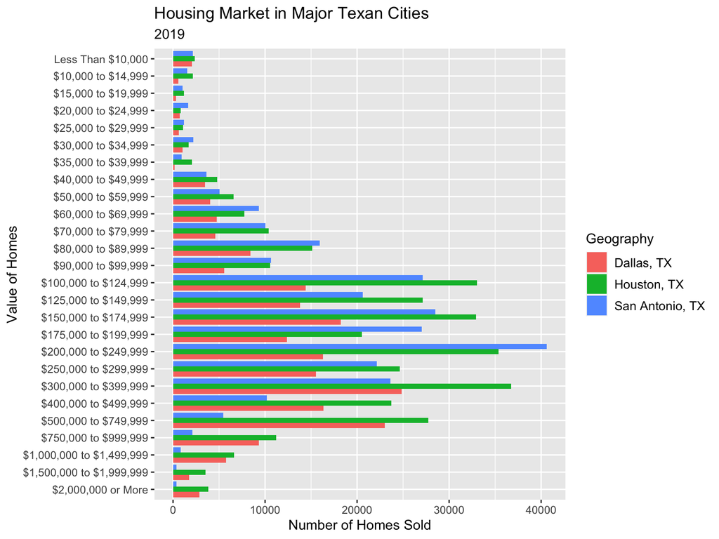

Quite apparent that homes are being sold at a higher rate within Houston. Let’s take a deeper look as to what these houses are going for.

# A closer look

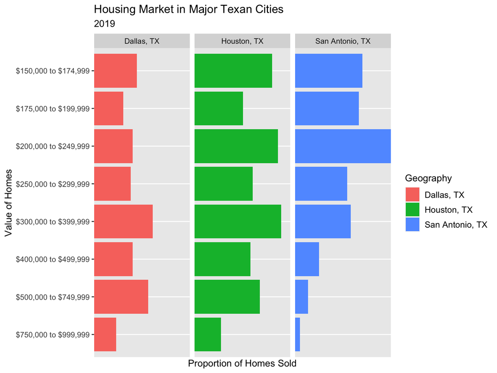

### In Houston most homes sold are sold at almost an even rate from $150,000 to $750,000

### In Dallas most homes sold are between $300,000 to $750,000

### In San Antonio most homes sold are between $200,000 to $250,000

Lots more options for ‘affordable housing’ in the San Antonio and Houston area! Directly correlating to the massive construction industry.

# Commuting

A commute can make a break the experience in a city. Constant traffic not only causes longer delays in driving, but also raises stress levels and environmental pollution.

# Gas Attack

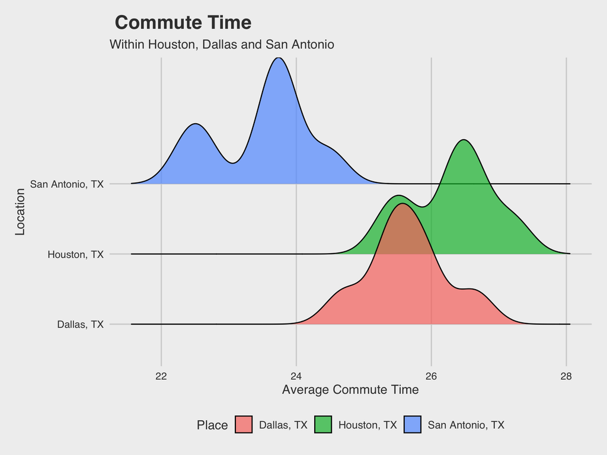

Houston Traffic; Can’t be beat!

# Demographics!

Who will be your neighbor? What will the culture of the city feel like?

# Lets check out the Diversity!

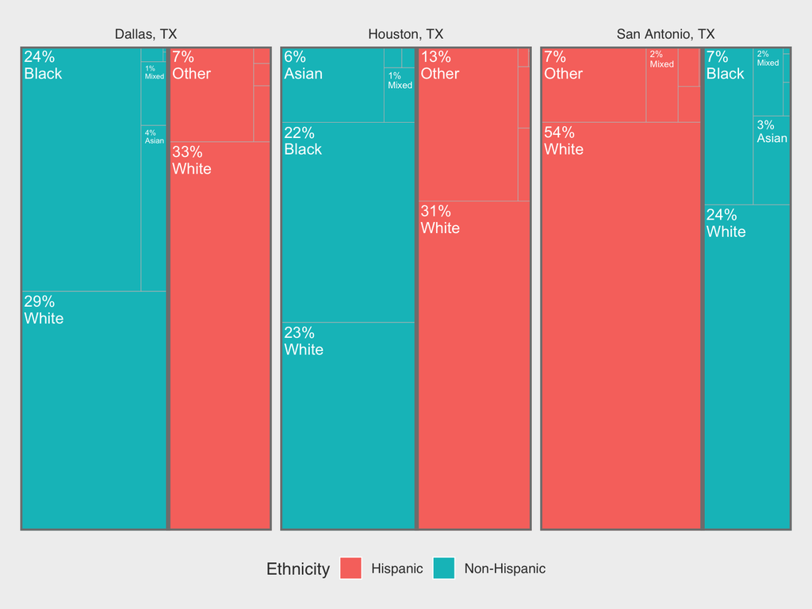

San Antonio with a strong Hispanic presence. Over half of their population coming from Hispanic descent! Houston also matches diversity levels with San Antonio. Houston however, has the largest share of ethnicity inside its city limits. Lastly, Dallas will be the city with the weakest Hispanic presence.

# Summary

[output not shown]

# References

```
https://www.moving.com/tips/how-to-choose-the-right-city-for-you/
```